# final_project_stat

Agustin Campagnolo

2023-01-18

#### REFS

[1] https://www.analyticsvidhya.com/blog/2020/10/feature-selection-techniques-in-machine-learning/

- dispersion:
- n.a.
- outlier
- correlation
  - X -> remove multi-collinearity
  - Y
- Normalization/Standardization
  - coefficients scale (+explainability)

### Feature Selection

Load Dataset

```r
path <- '../..' # go up two folders
filename = '/winequality-white.csv'

data = read.csv(paste(path,filename, sep = ""), sep = ';') # load data

names(data) # view variable names
```

```
##  [1] "fixed.acidity"        "volatile.acidity"     "citric.acid"
##  [4] "residual.sugar"       "chlorides"            "free.sulfur.dioxide"
##  [7] "total.sulfur.dioxide" "density"              "pH"
## [10] "sulphates"            "alcohol"              "quality"
```

```r
dim(data) # view datframe size [rows, columns]
```

```
## [1] 4898   12
```

```r
head(data) # view first lines
```

```
##   fixed.acidity volatile.acidity citric.acid residual.sugar chlorides
## 1           7.0             0.27        0.36           20.7     0.045
## 2           6.3             0.30        0.34            1.6     0.049
## 3           8.1             0.28        0.40            6.9     0.050
## 4           7.2             0.23        0.32            8.5     0.058
## 5           7.2             0.23        0.32            8.5     0.058
## 6           8.1             0.28        0.40            6.9     0.050
##   free.sulfur.dioxide total.sulfur.dioxide density   pH sulphates alcohol
## 1                  45                  170  1.0010 3.00      0.45     8.8
## 2                  14                  132  0.9940 3.30      0.49     9.5
## 3                  30                   97  0.9951 3.26      0.44    10.1
## 4                  47                  186  0.9956 3.19      0.40     9.9
## 5                  47                  186  0.9956 3.19      0.40     9.9
## 6                  30                   97  0.9951 3.26      0.44    10.1
##   quality
## 1       6
## 2       6
## 3       6
## 4       6
## 5       6
## 6       6
```

```r
str(data) # structure of dataframe
```

```
## 'data.frame':    4898 obs. of  12 variables:
##  $ fixed.acidity       : num  7 6.3 8.1 7.2 7.2 8.1 6.2 7 6.3 8.1 ...
##  $ volatile.acidity    : num  0.27 0.3 0.28 0.23 0.23 0.28 0.32 0.27 0.3 0.22 ...
##  $ citric.acid         : num  0.36 0.34 0.4 0.32 0.32 0.4 0.16 0.36 0.34 0.43 ...
##  $ residual.sugar      : num  20.7 1.6 6.9 8.5 8.5 6.9 7 20.7 1.6 1.5 ...
##  $ chlorides           : num  0.045 0.049 0.05 0.058 0.058 0.05 0.045 0.045 0.049 0.044 ...
##  $ free.sulfur.dioxide : num  45 14 30 47 47 30 30 45 14 28 ...
##  $ total.sulfur.dioxide: num  170 132 97 186 186 97 136 170 132 129 ...
##  $ density             : num  1.001 0.994 0.995 0.996 0.996 ...
##  $ pH                  : num  3 3.3 3.26 3.19 3.19 3.26 3.18 3 3.3 3.22 ...
##  $ sulphates           : num  0.45 0.49 0.44 0.4 0.4 0.44 0.47 0.45 0.49 0.45 ...
##  $ alcohol             : num  8.8 9.5 10.1 9.9 9.9 10.1 9.6 8.8 9.5 11 ...
##  $ quality             : int  6 6 6 6 6 6 6 6 6 6 ...
```

```r
summary(data) # descriptive statistics
```

```
##  fixed.acidity    volatile.acidity  citric.acid     residual.sugar
##  Min.   : 3.800   Min.   :0.0800   Min.   :0.0000   Min.   : 0.600
##  1st Qu.: 6.300   1st Qu.:0.2100   1st Qu.:0.2700   1st Qu.: 1.700
##  Median : 6.800   Median :0.2600   Median :0.3200   Median : 5.200
##  Mean   : 6.855   Mean   :0.2782   Mean   :0.3342   Mean   : 6.391
##  3rd Qu.: 7.300   3rd Qu.:0.3200   3rd Qu.:0.3900   3rd Qu.: 9.900
##  Max.   :14.200   Max.   :1.1000   Max.   :1.6600   Max.   :65.800
##    chlorides       free.sulfur.dioxide total.sulfur.dioxide    density
##  Min.   :0.00900   Min.   :  2.00      Min.   :  9.0        Min.   :0.9871
##  1st Qu.:0.03600   1st Qu.: 23.00      1st Qu.:108.0        1st Qu.:0.9917
##  Median :0.04300   Median : 34.00      Median :134.0        Median :0.9937
##  Mean   :0.04577   Mean   : 35.31      Mean   :138.4        Mean   :0.9940
##  3rd Qu.:0.05000   3rd Qu.: 46.00      3rd Qu.:167.0        3rd Qu.:0.9961
##  Max.   :0.34600   Max.   :289.00      Max.   :440.0        Max.   :1.0390
##        pH          sulphates         alcohol         quality
##  Min.   :2.720   Min.   :0.2200   Min.   : 8.00   Min.   :3.000
##  1st Qu.:3.090   1st Qu.:0.4100   1st Qu.: 9.50   1st Qu.:5.000
##  Median :3.180   Median :0.4700   Median :10.40   Median :6.000
##  Mean   :3.188   Mean   :0.4898   Mean   :10.51   Mean   :5.878
##  3rd Qu.:3.280   3rd Qu.:0.5500   3rd Qu.:11.40   3rd Qu.:6.000
##  Max.   :3.820   Max.   :1.0800   Max.   :14.20   Max.   :9.000
```

Cleaning exploration

```r
colSums(is.na(data)) # count Na values by columns
```

```
##        fixed.acidity     volatile.acidity          citric.acid
##                    0                    0                    0
##       residual.sugar            chlorides  free.sulfur.dioxide
##                    0                    0                    0
## total.sulfur.dioxide              density                   pH
##                    0                    0                    0
##            sulphates              alcohol              quality
##                    0                    0                    0
```

## Data Exploration

- Inspect every variable

```r
library(tidyverse)
library(hrbrthemes)
```

```r
plot_feature_hist <- function(data, col, name, color) {
  bw <- 2 * IQR(data[,col]) / length(data[,col])^(1/3) # Freedman-Diaconis’s Rule
  return(
    p <- data %>%
      ggplot( aes_string(x=col)) +
        geom_histogram(binwidth=bw, fill=color, color="#e9ecef", alpha=0.9) +
        ggtitle(name) +
        theme_ipsum() +
        theme(
          plot.title = element_text(size=15)
        )
    )
}
```

##### Quality

Quality in white wines can be a complex concept, as it can be affected by various factors such as grape variety, winemaking techniques, climate, soil, and vintage. In general, quality in white wines refers to the overall balance, complexity, and character of the wine.

Some of the characteristics that are often associated with high-quality white wines include:

Aroma: The wine should have a pleasant aroma that is typical of the grape variety used and should be free of any off odors or defects. Taste: The wine should have a well-balanced taste, with a good acidity-alcohol-sweetness balance, and with a long and pleasant finish. Appearance: The wine should be clear and bright, with a good color intensity. Ageability: The wine should have the potential to age well and develop more complex flavors and aromas over time. However, quality is also a subjective concept that can vary depending on individual preferences. Some people may prefer a wine with a high acidity, while others may prefer a wine with a higher alcohol content. Quality can also depend on the occasion and the food pairings, as some wines that may be considered high-quality for one occasion may not be for another.

In the wine industry, wines are often rated by experts and critics, who assign scores and awards to wines based on their quality. These ratings can be a useful tool for consumers to guide their purchasing decisions, but it’s important to remember that ultimately quality is a personal preference.

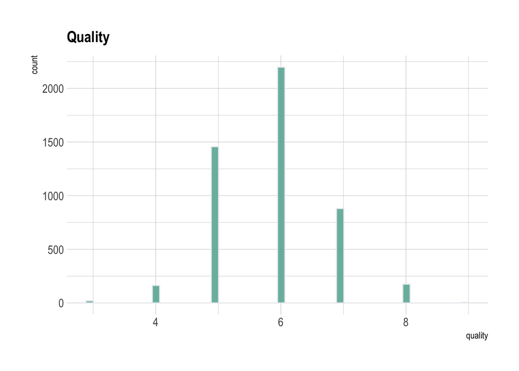

```r
print(plot_feature_hist(data, "quality","Quality", "#69b3a2"))
```

##### Fixed acidity

*from GPT3:*

Fixed acidity in white wines refers to the total acidity present in the wine that is not in the form of volatile acidity (acetic acid). The most common acids found in wine are tartaric, malic, and citric acid. The acidity level in white wines is an important factor that contributes to the overall taste and balance of the wine. High acidity can give the wine a crisp and refreshing taste, while low acidity can make the wine taste flabby or dull. The fixed acidity levels are measured in grams per liter (g/L) or in percentage by weight (% w/w).

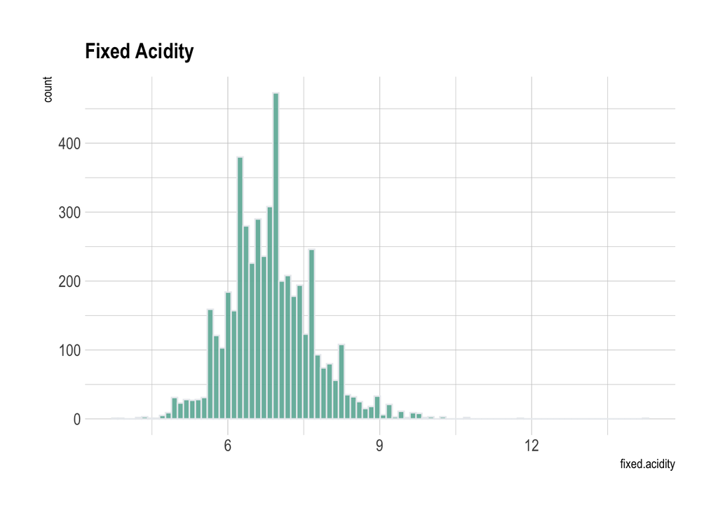

```r
print(plot_feature_hist(data, "fixed.acidity","Fixed Acidity", "#69b3a2"))
```

##### Volatile acidity

*from GPT3:*

Volatile acidity (VA) in white wines refers to the amount of acetic acid present in the wine. Acetic acid is a type of volatile acid that can be produced by the presence of acetic acid bacteria (such as acetobacter) during the wine-making process. High levels of VA can give the wine a vinegary or “off” flavor, while low levels of VA are desirable for most white wines. The volatile acidity levels are measured in grams per liter (g/L) or in parts per million (ppm). VA is typically much lower than fixed acidity in white wines.

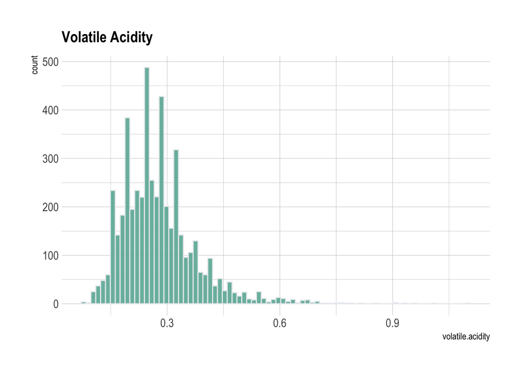

```r
print(plot_feature_hist(data, "volatile.acidity","Volatile Acidity", "#69b3a2"))
```

##### Citirc acid

*from GPT3:*

Citric acid is a type of fixed acid that can be found in white wines. It is one of the three main acids found in wine, along with tartaric and malic acid. Citric acid is a weak organic acid that is present in many fruits, including grapes, and it is naturally present in grapes at the time of harvest. During the fermentation process, yeast converts the natural sugars present in grapes into alcohol and carbon dioxide, and it also converts a small amount of citric acid into carbon dioxide. Citric acid contributes to the overall acidity of the wine and can give the wine a fresh, bright and tangy flavor. Citric acid levels are measured in grams per liter (g/L) or in percentage by weight (% w/w).

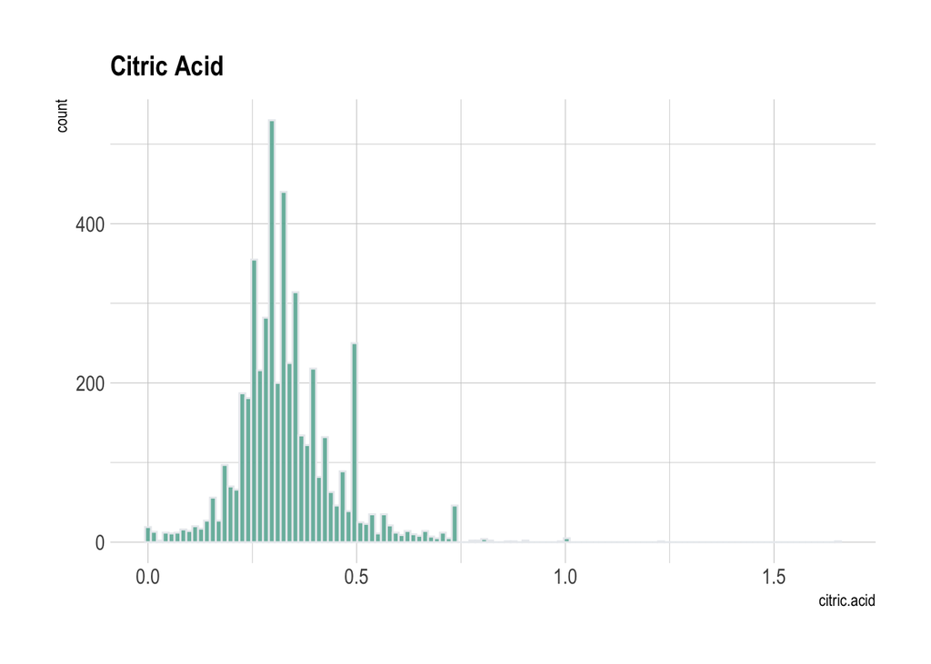

```r
print(plot_feature_hist(data, "citric.acid","Citric Acid", "#69b3a2"))
```

##### Residual sugar

*from GPT3:*

Residual sugar (RS) in white wines refers to the amount of natural sugar that remains in the wine after fermentation. During the wine-making process, yeast consumes the natural sugars present in grapes, converting them into alcohol and carbon dioxide. However, not all of the sugars may be fermented, leaving a certain amount of residual sugar in the final product. The residual sugar levels can vary greatly depending on the type of wine and the winemaking method used.

Dry white wines typically have low levels of residual sugar, while sweeter white wines will have higher levels. The residual sugar levels are measured in grams per liter (g/L) or in percentage by weight (% w/w). Residual sugar can affect the taste, body, and overall balance of the wine, and it also can affect the perception of acidity and alcohol in the wine.

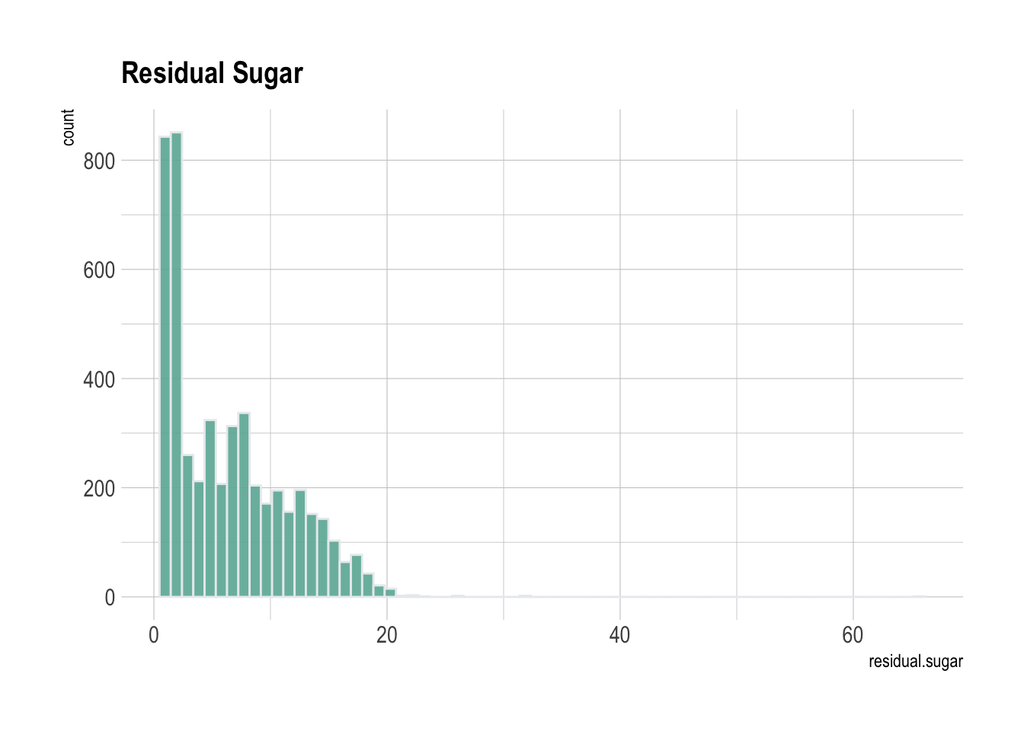

```r
print(plot_feature_hist(data, "residual.sugar","Residual Sugar", "#69b3a2"))
```

##### Chlorides

*from GPT3:*

Chlorides in white wines refer to the chloride ions present in the wine. Chlorides are a type of salt that can be found in small amounts in grapes and can also be added during the winemaking process as a stabilizing agent. Chlorides can affect the perception of acidity, bitterness and sweetness in the wine.

Chlorides can be added to wine in the form of potassium chloride or sodium chloride. Potassium chloride is commonly used in white wines to enhance the perception of sweetness and to reduce the perception of bitterness and acidity. Sodium chloride is used in smaller amounts and it is mainly used to enhance the perception of flavors and aromas in the wine.

High levels of chlorides can make the wine taste salty or metallic, while low levels of chlorides are desirable for most white wines. The chloride levels are measured in milligrams per liter (mg/L) or in parts per million (ppm).

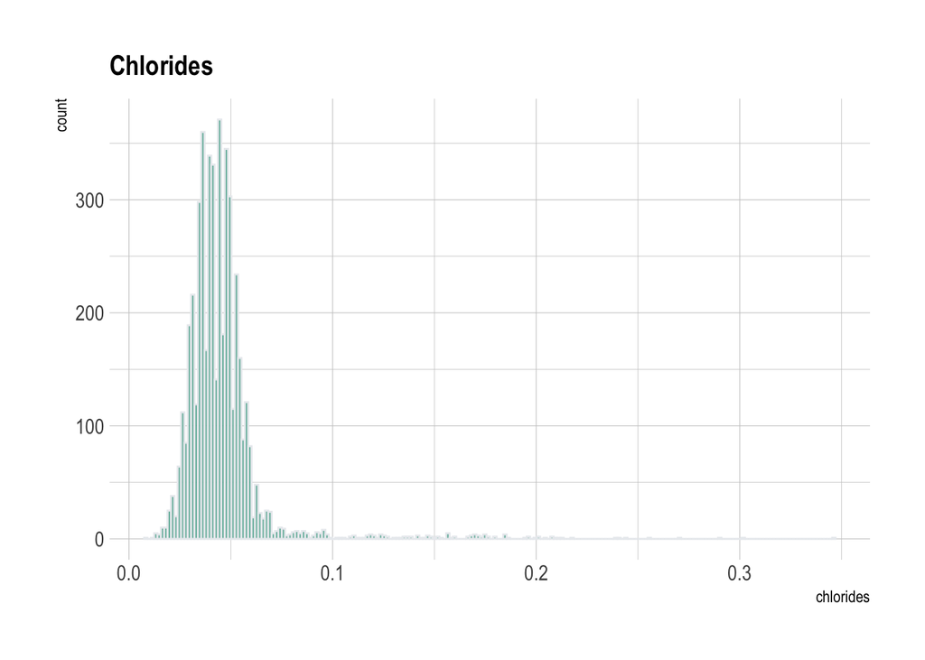

```r
print(plot_feature_hist(data, "chlorides","Chlorides", "#69b3a2"))
```

##### Free Sulfur dioxides

*from GPT3:*

Free sulfur dioxide (FSO2) in white wines refers to the amount of sulfur dioxide that is not chemically bound to other compounds in the wine. Sulfur dioxide (SO2) is a naturally occurring compound that is present in grapes, but it is also commonly added to wine as a preservative. Sulfur dioxide can prevent the growth of unwanted microorganisms, such as bacteria and wild yeast, and can also protect the wine from oxidation.

During the winemaking process, sulfur dioxide is added to the wine in the form of sulfur dioxide gas, potassium metabisulfite, or sodium metabisulfite. Some of the sulfur dioxide will bind to other compounds in the wine, forming “bound sulfur dioxide”, and some of it will remain as “free sulfur dioxide”.

The levels of free sulfur dioxide are measured in milligrams per liter (mg/L) or in parts per million (ppm). The acceptable levels of free sulfur dioxide vary depending on the type of wine and the wine-making method used, but generally, it is between 30-50 mg/L for white wines. High levels of free sulfur dioxide can give the wine a “sulfury” or “burnt match” smell, while low levels can make the wine more susceptible to spoilage.

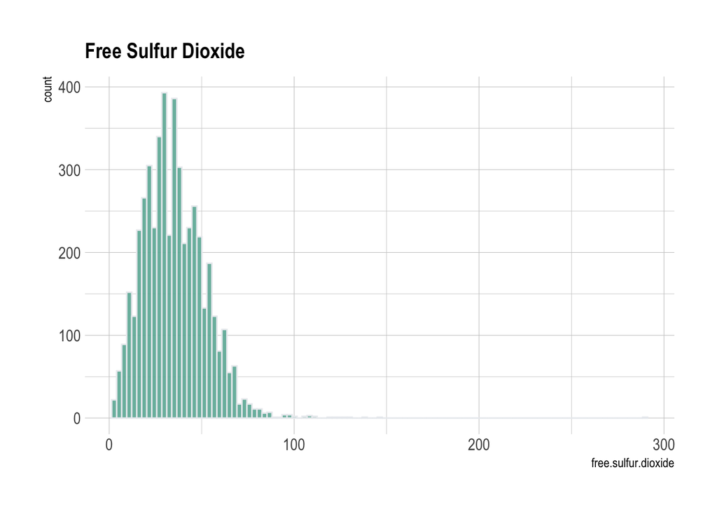

```r
print(plot_feature_hist(data, "free.sulfur.dioxide","Free Sulfur Dioxide", "#69b3a2"))
```

##### Total Sulfur dioxides

*from GPT3:*

Total sulfur dioxide (TSO2) in white wines refers to the combined amount of free sulfur dioxide (FSO2) and bound sulfur dioxide (BSO2) present in the wine. Sulfur dioxide (SO2) is a naturally occurring compound that is present in grapes, but it is also commonly added to wine as a preservative. Sulfur dioxide can prevent the growth of unwanted microorganisms, such as bacteria and wild yeast, and can also protect the wine from oxidation.

During the winemaking process, sulfur dioxide is added to the wine in the form of sulfur dioxide gas, potassium metabisulfite, or sodium metabisulfite. Some of the sulfur dioxide will bind to other compounds in the wine, forming “bound sulfur dioxide”, and some of it will remain as “free sulfur dioxide”.

Total sulfur dioxide levels are measured in milligrams per liter (mg/L) or in parts per million (ppm). The acceptable levels of total sulfur dioxide vary depending on the type of wine and the wine-making method used, but generally, it is between 80-150 mg/L for white wines. High levels of total sulfur dioxide can give the wine a “sulfury” or “burnt match” smell, while low levels can make the wine more susceptible to spoilage.

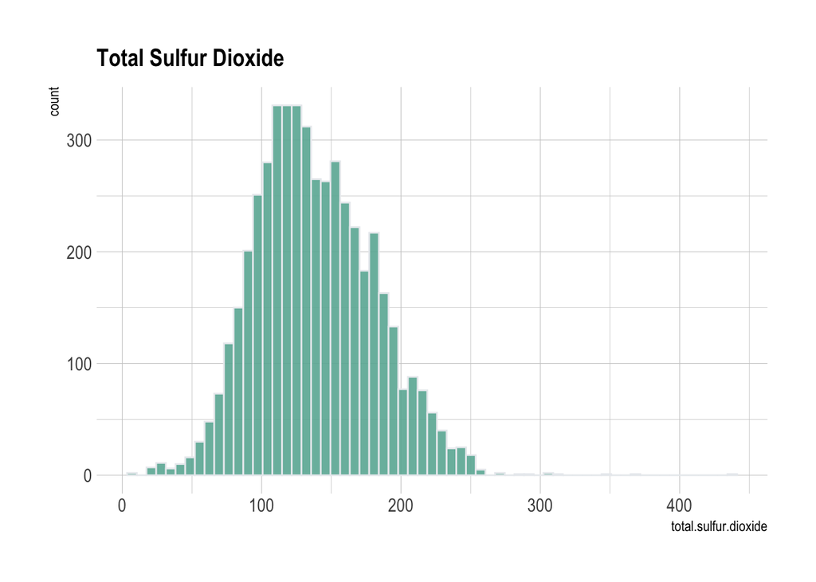

```r
print(plot_feature_hist(data, "total.sulfur.dioxide","Total Sulfur Dioxide", "#69b3a2"))
```

##### Density

*from GPT3:*

Density in white wines refers to the mass per unit volume of the liquid. The density of a liquid is a measure of how heavy it is compared to an equal volume of water. Density is typically measured in grams per milliliter (g/mL) or in kilograms per liter (kg/L).

In white wines, the density is mainly affected by the sugar content, alcohol content and temperature. Generally, the higher the sugar content, the higher the density of the wine, and the higher the alcohol content, the lower the density of the wine. Also, the density of a liquid is affected by temperature, as the density of a liquid decreases as the temperature increases.

Density measurement is used in winemaking as a way to monitor the progress of fermentation, as the density of the wine decreases as the sugar is converted into alcohol. It is also used to measure the alcohol content of the wine. With the density measurement, it is possible to estimate the alcohol content of the wine, which can be useful for labeling, taxation and regulatory purposes.

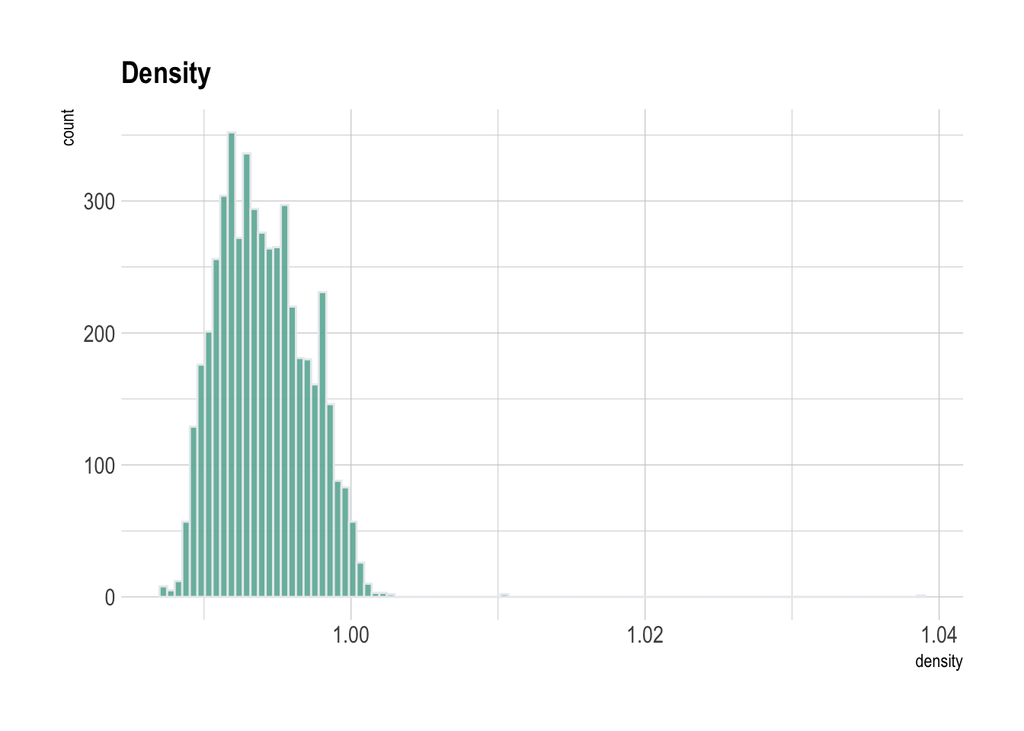

```r
print(plot_feature_hist(data, "density","Density", "#69b3a2"))
```

##### pH

*from GPT3:*

pH in white wines refers to the acidity or basicity of the wine. pH is a measure of the hydrogen ion concentration in a solution, and it ranges from 0 to 14, with 7 being neutral. Lower pH values indicate a more acidic solution, while higher pH values indicate a more basic solution. In white wines, the pH values typically range from about 2.8 to 3.8, making them acidic.

pH plays an important role in the taste and stability of white wines. Lower pH values contribute to a more acidic, crisp and fresh taste, while higher pH values can make the wine taste flabby or dull. It also affects the perception of other wine’s components, like the taste of sugar, tannins, and flavors. A low pH can enhance the perception of flavors and aromas, while a high pH can make the wine taste flat.

Additionally, pH also affects the stability of the wine, as wines with a low pH are more resistant to spoilage and oxidation. Microorganisms that can spoil the wine, like bacteria and wild yeast, tend to grow better in wine with a high pH.

pH measurement is an important analytical tool in winemaking, and it is used to monitor and control the acidity of the wine, to ensure that the wine has the right balance of acidity and to prevent spoilage.

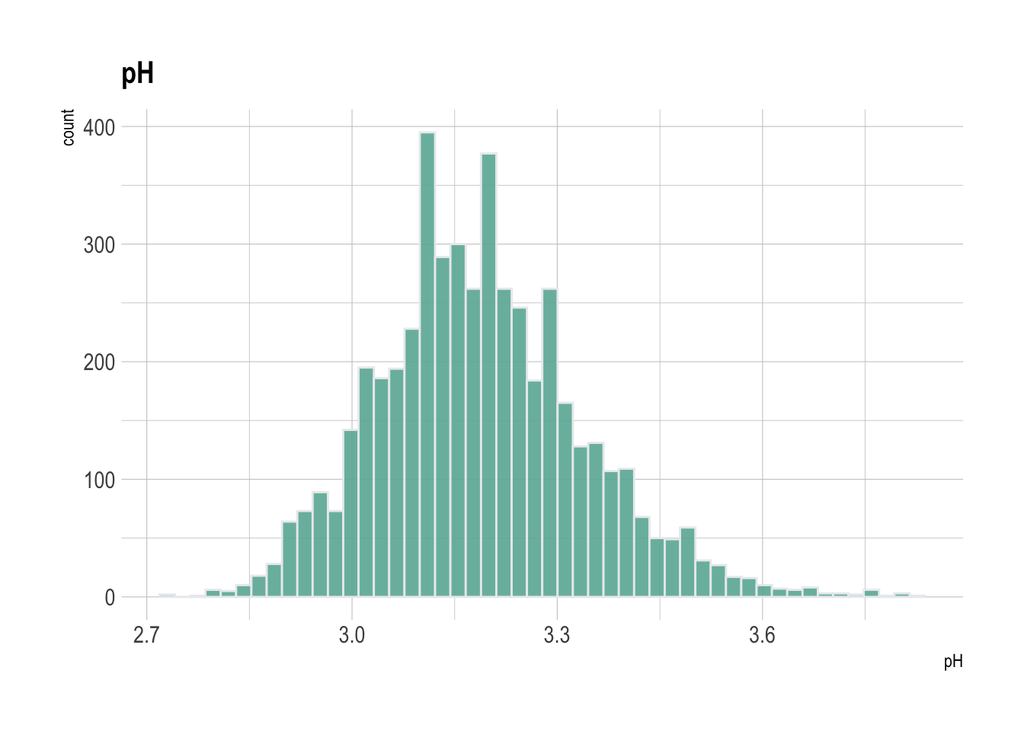

```r
print(plot_feature_hist(data, "pH","pH", "#69b3a2"))
```

##### Sulphates

*from GPT3:*

Sulfates in white wines refer to the sulfate ions present in the wine. Sulfates are a type of salt that can be found in grapes, but they are also commonly added to wine as a stabilizing agent, specifically as sulfur dioxide (SO2) which is a compound that contains sulfate ions. SO2 is naturally present in grapes, but it is also added to wine to prevent spoilage and oxidation by inhibiting the growth of unwanted microorganisms, such as bacteria and wild yeast.

Sulfates can be added to wine in the form of potassium metabisulfite, or sodium metabisulfite. These compounds are used as a preservative and antioxidant, and they help to protect the wine from spoilage and oxidation.

The levels of sulfates in wine are measured in milligrams per liter (mg/L) or in parts per million (ppm). The acceptable levels of sulfates vary depending on the type of wine, but generally, it is between 50-200 mg/L for white wines. High levels of sulfates can give the wine a “sulfury” or “burnt match” smell, while low levels can make the wine more susceptible to spoilage.

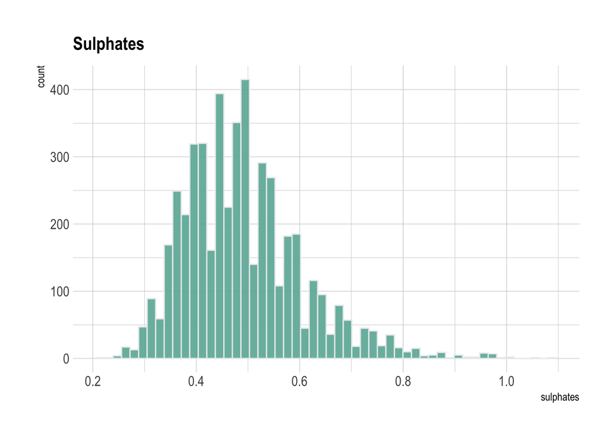

```r
print(plot_feature_hist(data, "sulphates","Sulphates", "#69b3a2"))
```

##### Alcohol

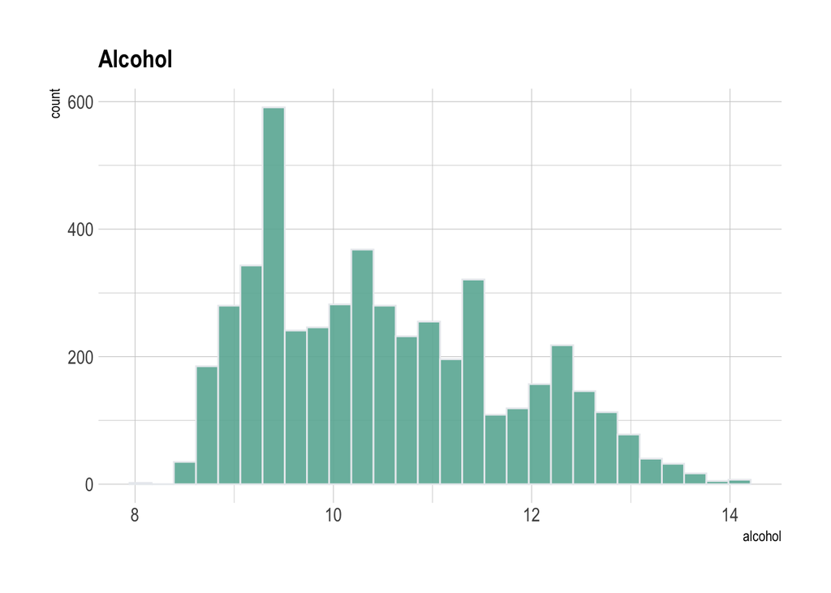

```r
print(plot_feature_hist(data, "alcohol","Alcohol", "#69b3a2"))
```

### Correlation Coefficient

Correlation is a measure of the linear relationship of 2 or more variables. Through correlation, we can predict one variable from the other. The logic behind using correlation for feature selection is that the good variables are highly correlated with the target. Furthermore, variables should be correlated with the target but should be uncorrelated among themselves.

If two variables are correlated, we can predict one from the other. Therefore, if two features are correlated, the model only really needs one of them, as the second one does not add additional information. We will use the Pearson Correlation here.[1]

```r
### install.packages("GGally")             # Install GGally package
library("GGally")
```

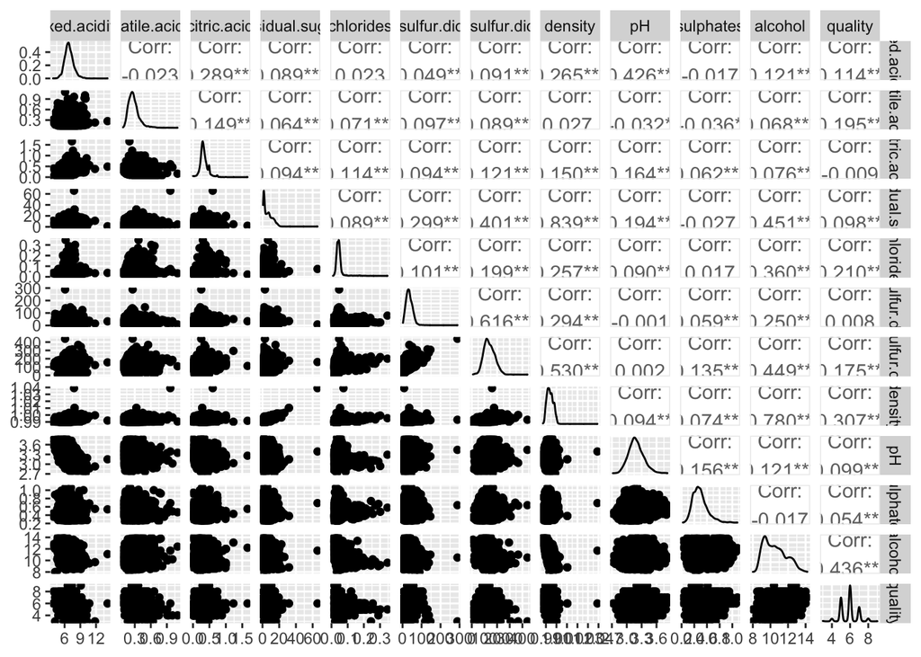

```r
ggp = ggpairs(data, progress = ggmatrix_progress())  # draw pair plots of dataframe
print(ggp)  # no progress bar
```

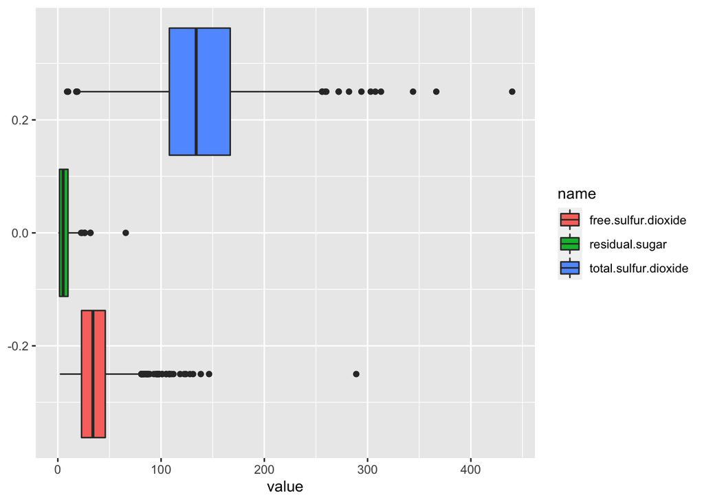

```r
### install.packages("tidyr")              # Install & load tidyr
library("tidyr")

cols <- names(data)
#del_cols <- (, "free.sulfur.dioxide", "alcohol", "quality", "fixed.acidity")
cols <- cols[cols != "total.sulfur.dioxide"];
cols <- cols[cols != "free.sulfur.dioxide"];
cols <- cols[cols != "residual.sugar"];
cols <- cols[cols != "alcohol"];
cols <- cols[cols != "quality"];
cols <- cols[cols != "fixed.acidity"];

data_long1 <- pivot_longer(data,    # Reshape data frame
                            c("total.sulfur.dioxide", "free.sulfur.dioxide", "residual.sugar"))

ggplot(data_long1,                  # Draw boxplots
       aes(x = value, fill = name)) + geom_boxplot()
```

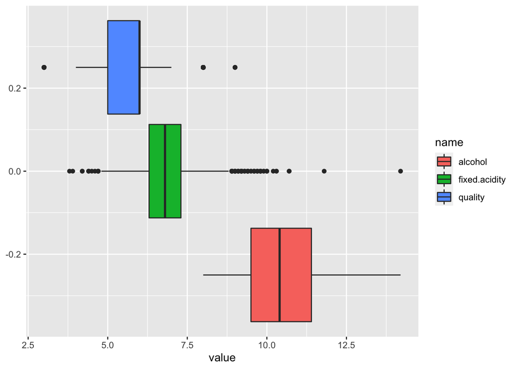

```r
data_long2 <- pivot_longer(data,    # Reshape data frame
                            c("alcohol", "quality", "fixed.acidity"))
ggplot(data_long2,                  # Draw boxplots
       aes(x = value, fill = name)) + geom_boxplot()
```

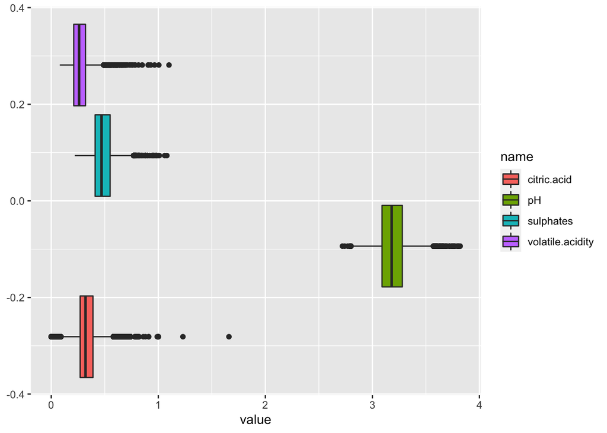

```r
data_long3 <- pivot_longer(data,    # Reshape data frame
                            c("volatile.acidity", "sulphates", "citric.acid", "pH"))
ggplot(data_long3,                  # Draw boxplots
       aes(x = value, fill = name)) + geom_boxplot()
```

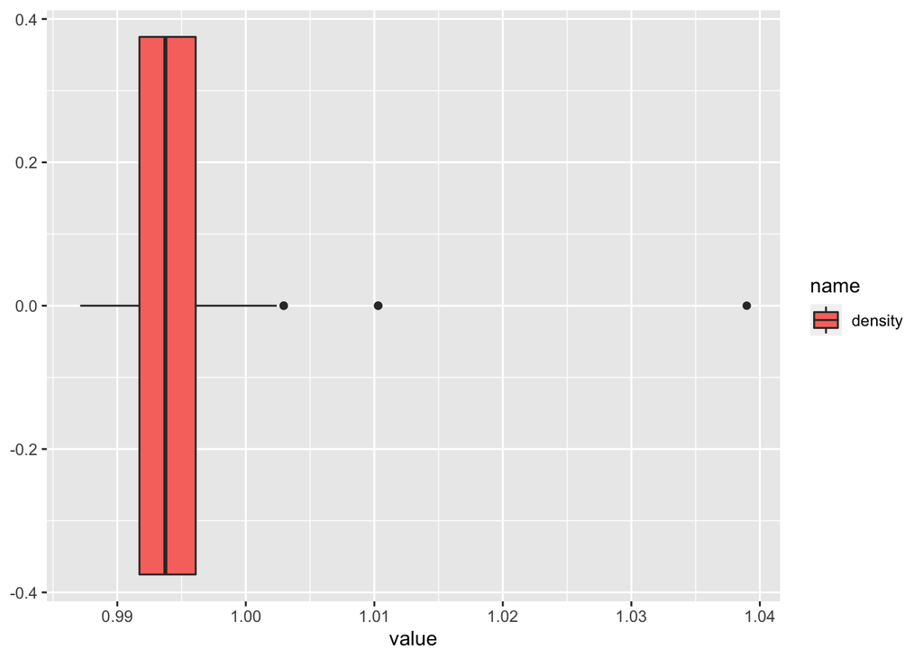

```r
data_long4 <- pivot_longer(data,    # Reshape data frame
                            c("density"))
ggplot(data_long4,                  # Draw boxplots
       aes(x = value, fill = name)) + geom_boxplot()
```

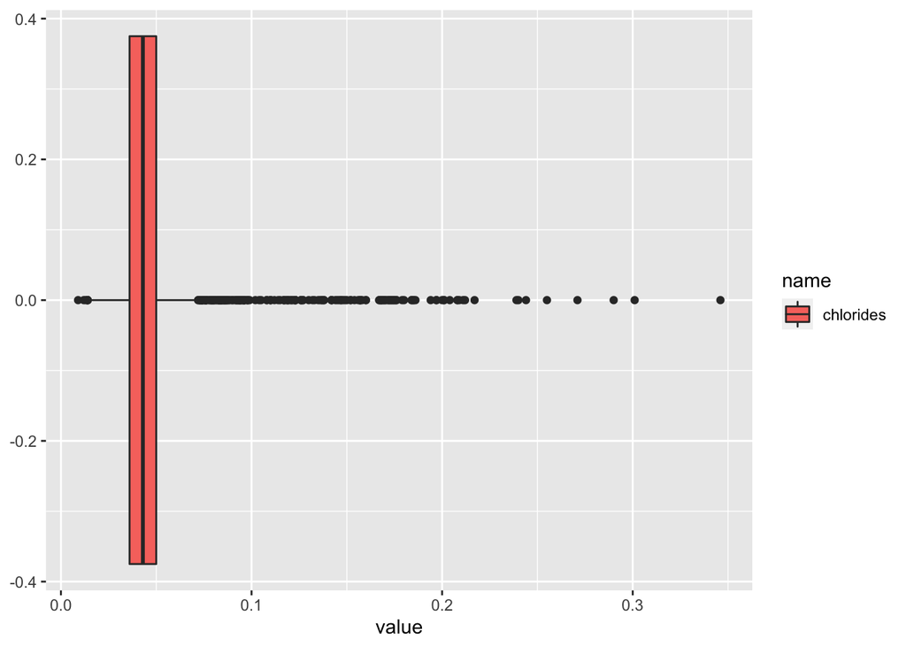

```r
data_long5 <- pivot_longer(data,    # Reshape data frame
                            c("chlorides"))
ggplot(data_long5,                  # Draw boxplots
       aes(x = value, fill = name)) + geom_boxplot()
```

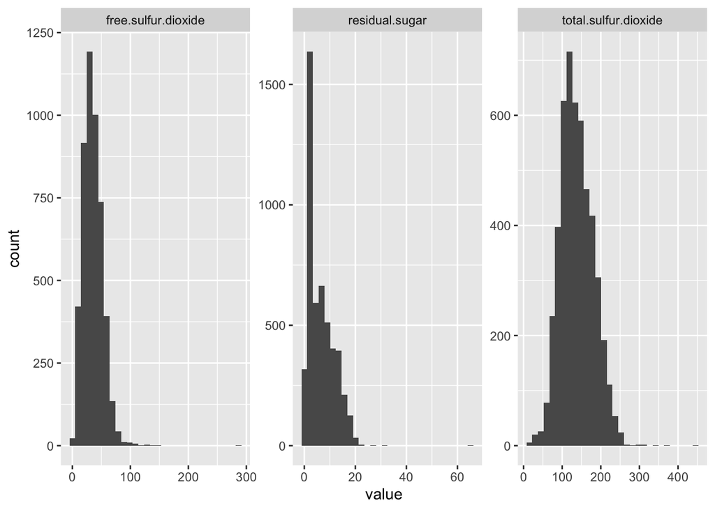

```r
ggplot(data_long1,                    # Draw histograms
       aes(x = value)) +
  geom_histogram() +
  facet_wrap(name ~ ., scales = "free")
```

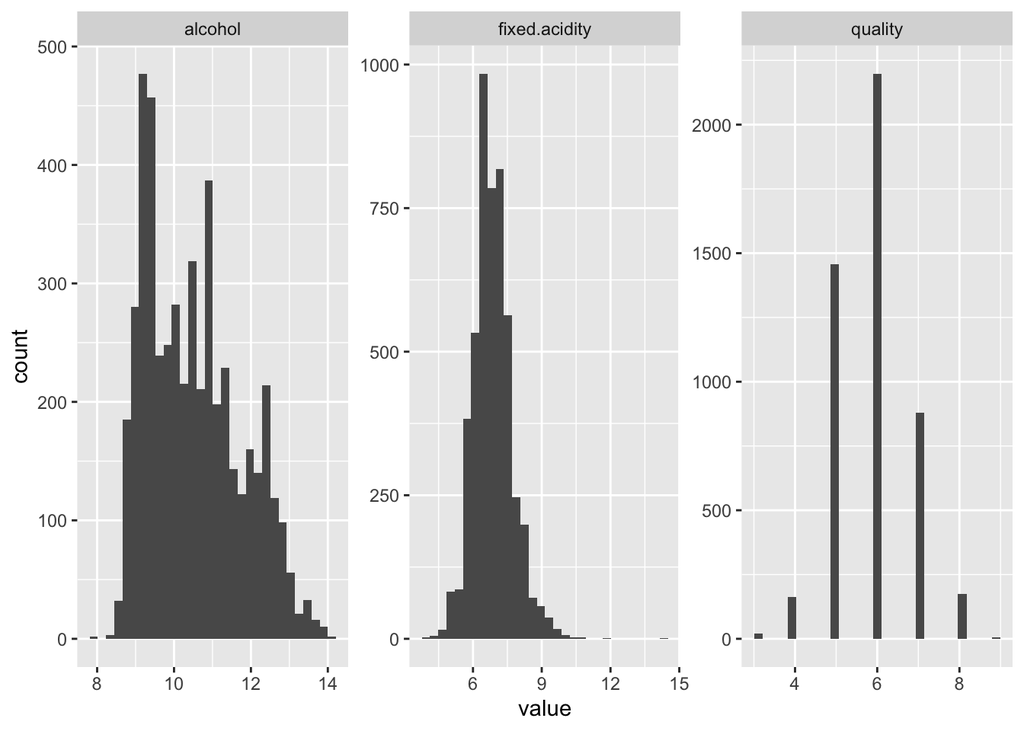

```r
ggplot(data_long2,                    # Draw histograms
       aes(x = value)) +
  geom_histogram() +
  facet_wrap(name ~ ., scales = "free")
```

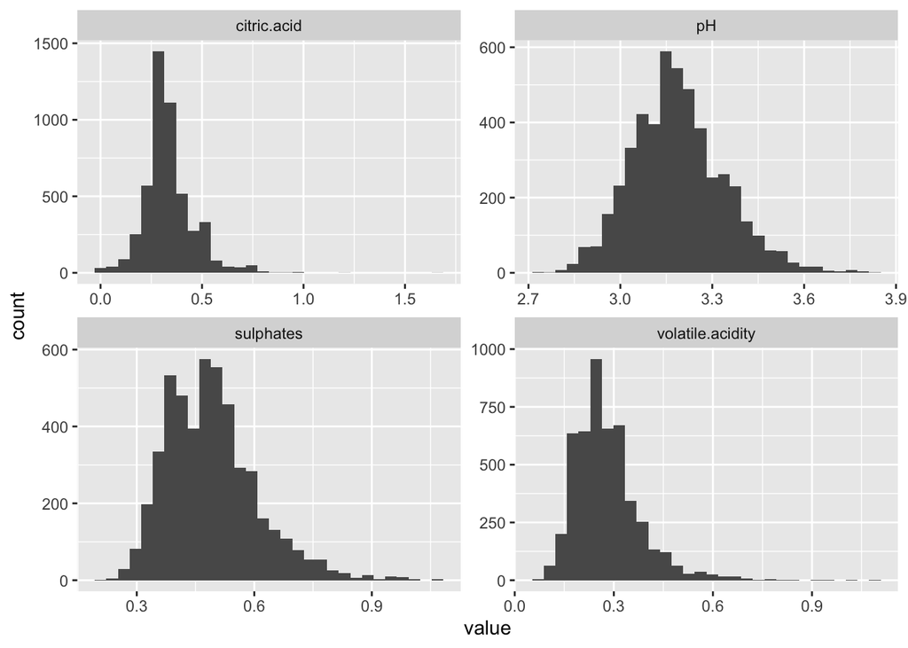

```r
ggplot(data_long3,                    # Draw histograms
       aes(x = value)) +
  geom_histogram() +
  facet_wrap(name ~ ., scales = "free")
```

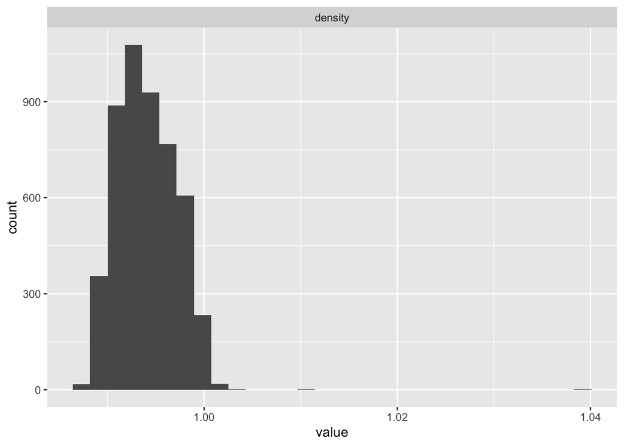

```r
ggplot(data_long4,                    # Draw histograms
       aes(x = value)) +
  geom_histogram() +
  facet_wrap(name ~ ., scales = "free")
```

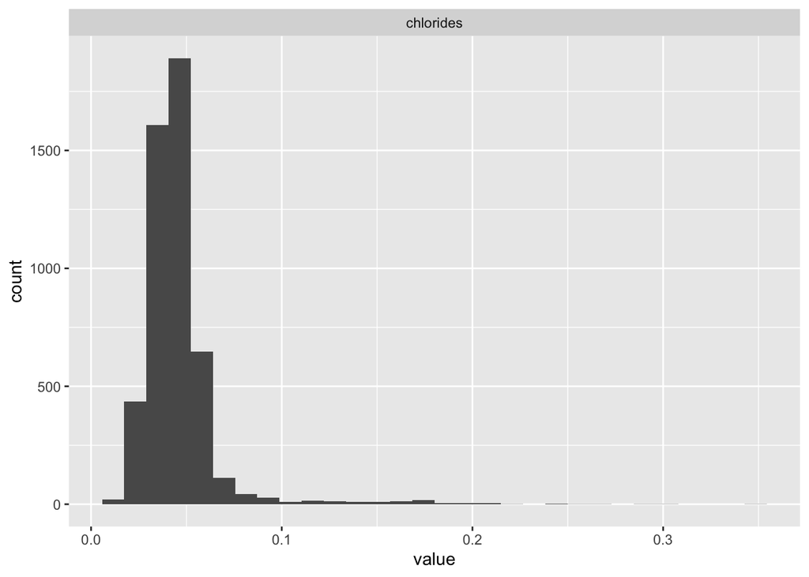

```r
ggplot(data_long5,                    # Draw histograms
       aes(x = value)) +
  geom_histogram() +
  facet_wrap(name ~ ., scales = "free")
```

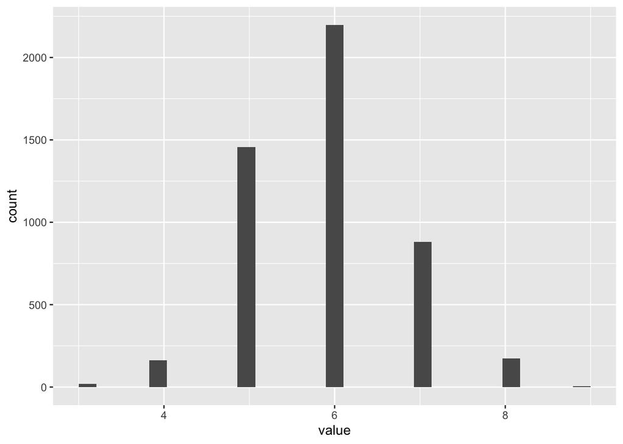

```r
data_response <- pivot_longer(data,    # Reshape data frame
                            c("quality"))
ggplot(data_response,                    # Draw histograms
       aes(x = value)) +
  geom_histogram()
```

```r
unique(data$quality)
```

```
## [1] 6 5 7 8 4 3 9
```

```r
#ggpairs(data)  # draw pair plots of dataframe

#gplot <- GGally::ggpairs(data)
#gplot$nrow <- 1
#gplot$yAxisLabels <- a$yAxisLabels[1]
#print(gplot)
```